# Subset Selection

### Choosing Among Models

Now that we’ve gone through indirectly calculating test errors, we begin Cross-Validate to get a direct test error

- Directly calculating a test error requires the data being split into a test and train set

```r
set.seed(1)
train = sample(c(TRUE,FALSE), nrow(Hitters),rep=TRUE)
test=(!train)
```

```r
regfit.best = regsubsets(Salary~.,data=Hitters[train,],nvmax=19)
test.mat = model.matrix(Salary~.,data=Hitters[test,])
val.errors=rep(NA,19)
for(i in 1:19){
  coefi=coef(regfit.best,id=i)
  pred=test.mat[,names(coefi)]%*%coefi
  val.errors[i]=mean((Hitters$Salary[test]-pred)^2)
}
```

After saving our validate errors in the variable val.errors, we plot the RMSE of the models associated with each number of variables

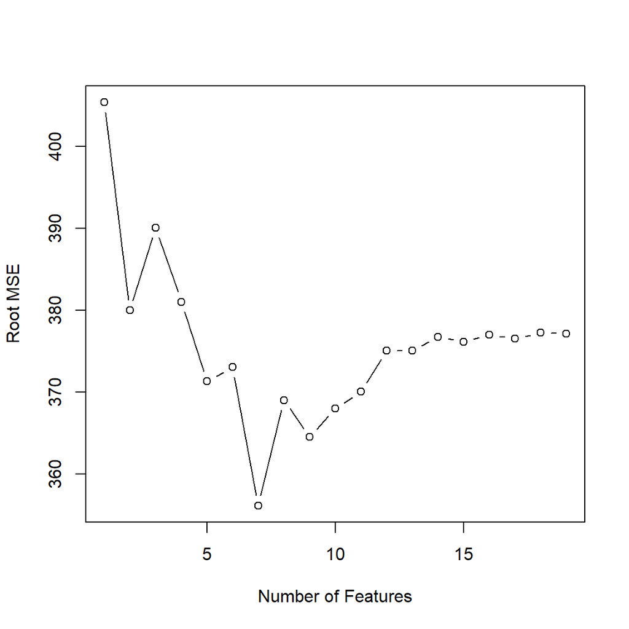

```r
plot(sqrt(val.errors), ylab="Root MSE", type="b", xlab="Number of Features")
```

```r
which.min(val.errors)
[1] 7
```

The coef() function displays all the model coefficients associated with the model passed as an argument

- This is useful because there is no method in R to form a prediction for regsubsets()
- We will then define a function to predict our outcomes for reproducibility

```r
coef(regfit.best,10)
 (Intercept)        AtBat         Hits        HmRun        Walks
  71.8074075   -1.5038124    5.9130470  -11.5241809    8.4349759
      CAtBat        CRuns         CRBI       CWalks    DivisionW
  -0.1654850    1.7064330    0.7903694   -0.9107515 -109.5616997
     PutOuts
   0.2426078

predict.regsubsets=function(object,newdata,id,...){
  form=as.formula(object$call[[2]])
  mat=model.matrix(form,newdata)
  coefi=coef(object,id=id)
  xvars=names(coefi)
  mat[,xvars]%*%coefi
}
```

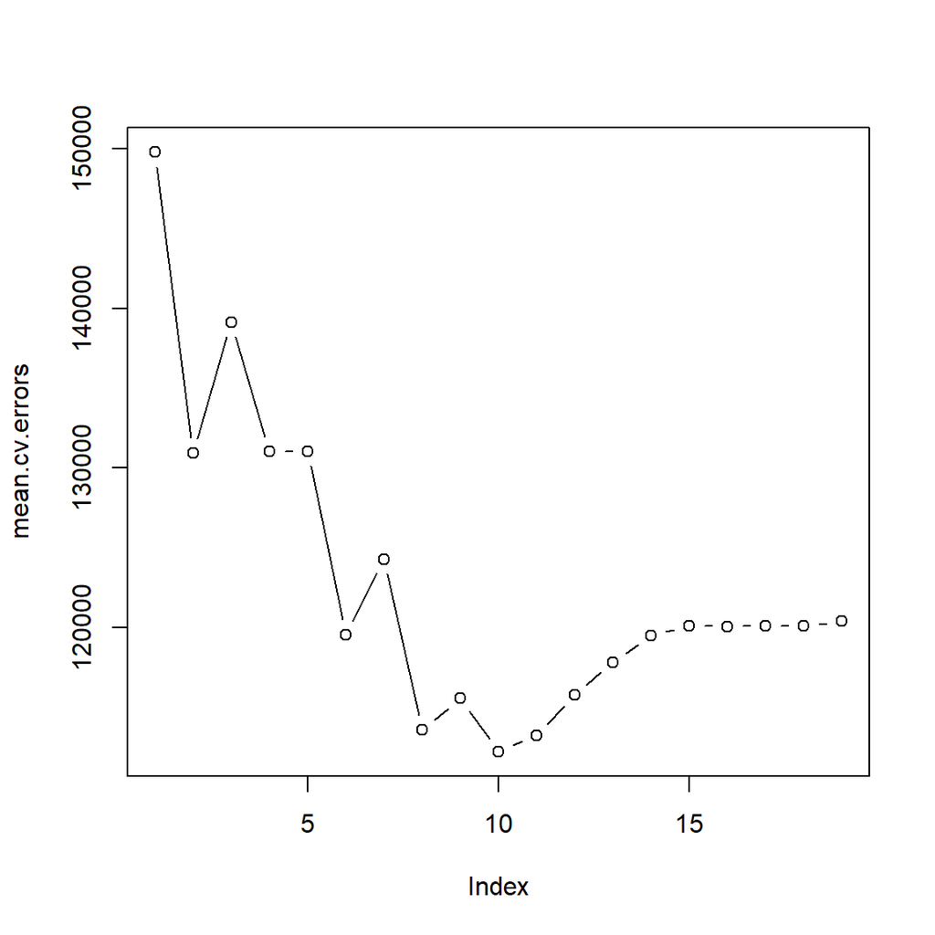

```r
regfit.best=regsubsets(Salary~.,data=Hitters,nvmax=19)
coef(regfit.best,10)
 (Intercept)        AtBat         Hits        Walks       CAtBat
 162.5354420   -2.1686501    6.9180175    5.7732246   -0.1300798
       CRuns         CRBI       CWalks    DivisionW      PutOuts
   1.4082490    0.7743122   -0.8308264 -112.3800575    0.2973726
     Assists
   0.2831680
k=10
set.seed(1)
folds=sample(1:k,nrow(Hitters),replace=TRUE)
cv.errors=matrix(NA,k,19, dimnames=list(NULL, paste(1:19)))
for(j in 1:k){
  best.fit=regsubsets(Salary~.,data=Hitters[folds!=j,],nvmax=19)
  for(i in 1:19){
    pred=predict(best.fit,Hitters[folds==j,],id=i)
    cv.errors[j,i]=mean( (Hitters$Salary[folds==j]-pred)^2)
  }
}
mean.cv.errors=apply(cv.errors,2,mean)
mean.cv.errors
       1        2        3        4        5        6        7        8
149821.1 130922.0 139127.0 131028.8 131050.2 119538.6 124286.1 113580.0
       9       10       11       12       13       14       15       16
115556.5 112216.7 113251.2 115755.9 117820.8 119481.2 120121.6 120074.3
      17       18       19
120084.8 120085.8 120403.5
par(mfrow=c(1,1))
plot(mean.cv.errors,type='b')
```

```r
reg.best=regsubsets(Salary~.,data=Hitters, nvmax=19)
coef(reg.best,11)
 (Intercept)        AtBat         Hits        Walks       CAtBat
 135.7512195   -2.1277482    6.9236994    5.6202755   -0.1389914
       CRuns         CRBI       CWalks      LeagueN    DivisionW
   1.4553310    0.7852528   -0.8228559   43.1116152 -111.1460252
     PutOuts      Assists
   0.2894087    0.2688277
```

# Applied Exercise: Exercise 6.8

In this exercise, we will generate simulated data, and will then use this data to perform best subset selection. a) Use the rnorm() function to generate a predictor X of length n = 100, as well as a noise vector $\epsilon$ of length n = 100.

```r
set.seed(1)
X = rnorm(100)
eps = rnorm(100)
```

2. Generate a response vector Y of length n = 100 according to the model Y = β0 + β1X + β2X2 + β3X3 + $\epsilon$, where β0, β1, β2, andβ3 are constants of your choice.
- We are selecting β0=3, β1=2, β2=−3 and β3=0.3.

```r
beta0 = 3
beta1 = 2
beta2 = -3
beta3 = 0.3
Y = beta0 + beta1 * X + beta2 * X^2 + beta3 * X^3 + eps
```

3. - Use regsubsets to select best model having polynomial of X of degree 10
   - What is the best model obtained according to Cp, BIC, and adjustedR2?

```r
data.full = data.frame(y = Y, x = X)
mod.full = regsubsets(y ~ poly(x, 10, raw = T), data = data.full, nvmax = 10)
mod.summary = summary(mod.full)

which.min(mod.summary$cp)
[1] 3
which.min(mod.summary$bic)
[1] 3
which.max(mod.summary$adjr2)
[1] 3
```

- Show some plots to provide evidence for your answer, and report the coeﬃcients of the best model obtained.

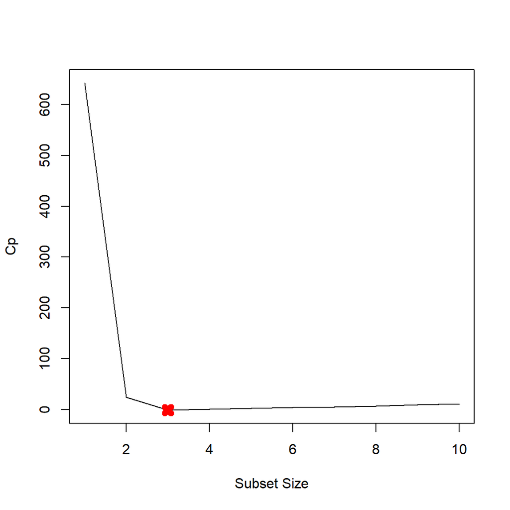

```r
plot(mod.summary$cp, xlab = "Subset Size", ylab = "Cp", pch = 20, type = "l")
points(3, mod.summary$cp[3], pch = 4, col = "red", lwd = 7)
```

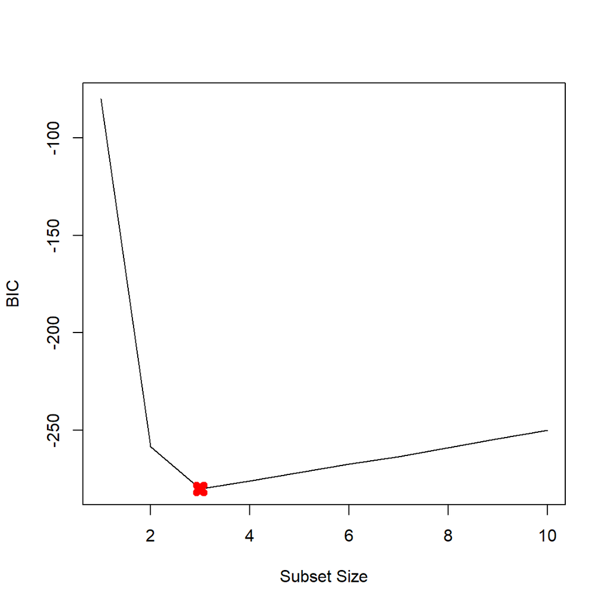

```r
plot(mod.summary$bic, xlab = "Subset Size", ylab = "BIC", pch = 20, type = "l")
points(3, mod.summary$bic[3], pch = 4, col = "red", lwd = 7)
```

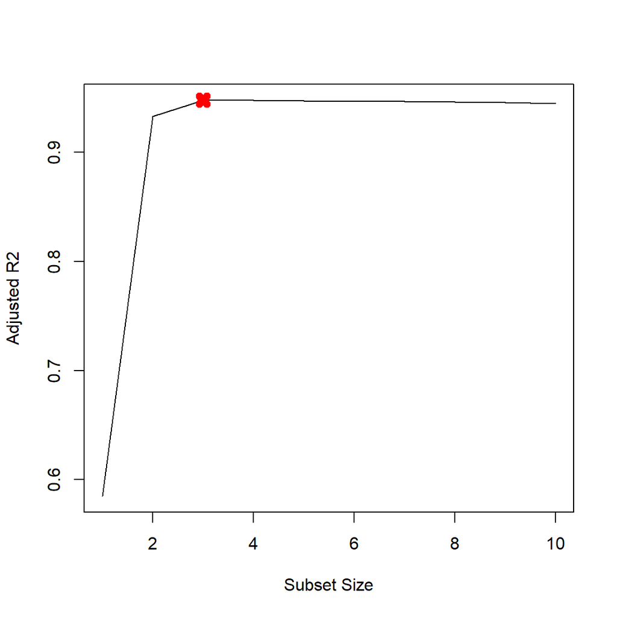

```r
plot(mod.summary$adjr2, xlab = "Subset Size", ylab = "Adjusted R2", pch = 20,
    type = "l")
points(3, mod.summary$adjr2[3], pch = 4, col = "red", lwd = 7)
```

```r
coefficients(mod.full, id = 3)
          (Intercept) poly(x, 10, raw = T)1 poly(x, 10, raw = T)2
           3.07627412            2.35623596           -3.16514887
poly(x, 10, raw = T)7
           0.01046843
```

We find that with Cp, BIC and Adjusted R2 criteria, 3, 3, and 3 variable models are respectively picked. All statistics pick X7 over X3. The remaining coefficients are quite close to β s.

4. Repeat (c), using forward stepwise selection and also using backwards stepwise selection.

```r
mod.fwd = regsubsets(y ~ poly(x, 10, raw = T), data = data.full, nvmax = 10,
    method = "forward")
mod.bwd = regsubsets(y ~ poly(x, 10, raw = T), data = data.full, nvmax = 10,
    method = "backward")
fwd.summary = summary(mod.fwd)
bwd.summary = summary(mod.bwd)
which.min(fwd.summary$cp)
[1] 3

which.min(bwd.summary$cp)
[1] 3

which.min(fwd.summary$bic)
[1] 3

which.min(bwd.summary$bic)
[1] 3

which.max(fwd.summary$adjr2)
[1] 3

which.max(bwd.summary$adjr2)
[1] 3
```

Plot the statistics

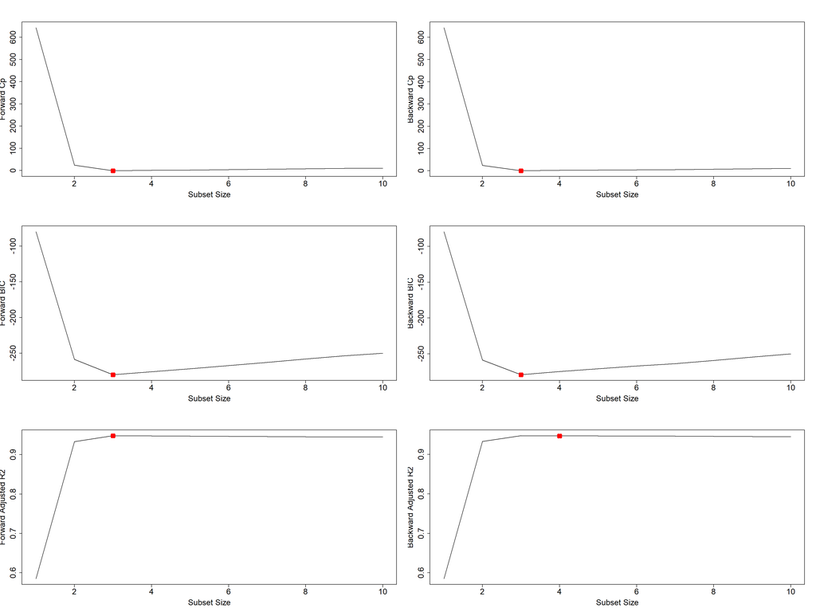

```r
par(mfrow = c(3, 2),cex.axis=1.8, cex.lab=1.8)
plot(fwd.summary$cp, xlab = "Subset Size", ylab = "Forward Cp", pch = 20, type = "l")
points(3, fwd.summary$cp[3], pch = 4, col = "red", lwd = 7)
plot(bwd.summary$cp, xlab = "Subset Size", ylab = "Backward Cp", pch = 20, type = "l")
points(3, bwd.summary$cp[3], pch = 4, col = "red", lwd = 7)
plot(fwd.summary$bic, xlab = "Subset Size", ylab = "Forward BIC", pch = 20,
    type = "l")
points(3, fwd.summary$bic[3], pch = 4, col = "red", lwd = 7)
plot(bwd.summary$bic, xlab = "Subset Size", ylab = "Backward BIC", pch = 20,
    type = "l")
points(3, bwd.summary$bic[3], pch = 4, col = "red", lwd = 7)
plot(fwd.summary$adjr2, xlab = "Subset Size", ylab = "Forward Adjusted R2",
    pch = 20, type = "l")
points(3, fwd.summary$adjr2[3], pch = 4, col = "red", lwd = 7)
plot(bwd.summary$adjr2, xlab = "Subset Size", ylab = "Backward Adjusted R2",
    pch = 20, type = "l")
points(4, bwd.summary$adjr2[4], pch = 4, col = "red", lwd = 7)
```

```r
coefficients(mod.fwd, id = 3)
          (Intercept) poly(x, 10, raw = T)1 poly(x, 10, raw = T)2
           3.07627412            2.35623596           -3.16514887
poly(x, 10, raw = T)7
           0.01046843

coefficients(mod.bwd, id = 3)
          (Intercept) poly(x, 10, raw = T)1 poly(x, 10, raw = T)2
          3.078881355           2.419817953          -3.177235617
poly(x, 10, raw = T)9
          0.001870457

coefficients(mod.fwd, id = 4)
          (Intercept) poly(x, 10, raw = T)1 poly(x, 10, raw = T)2
          3.112358625           2.369858879          -3.275726574
poly(x, 10, raw = T)4 poly(x, 10, raw = T)7
          0.027673638           0.009997134
```